# Greenhouse gas emissions model - making scenarios

Cory Whitney and Eike Luedeling

We’re defining the function as in the ‘Greenhouse gas emissions model’ document. Please look there for more information about the original model design.

We load the library and the data. The data contains ranges of possible values for the simulation. Each variable is represented with a confidence interval range and a specification of the distribution shape.

## Running the model with scenarios

The normal `mcSimulation` function takes random draws for each of the input variables from the distributions specified in the input table. The distributions that are used are the same for every run of the Monte Carlo simulation. Sometimes it’s desirable to specify particular scenarios *a priori*, e.g. to simulate outcomes for particular farm types, climate scenarios etc. To do this, we would normally have to define separate input tables and run separate simulations. This is quite inconvenient. Here, we’ll develop a function that can do this job automatically.

The new `scenario_sampler` function will consist of a wrapper around the `mcSimulation` function, which will be able to modify the input table according to a scenario file we provide. This file will contain information on which variables should be modified for each scenario and how many model runs should be included in the simulation.

```r
scenario_sampler<-function(base_estimate, scenarios, model_function, ..., numberOfModelRuns=NA, randomMethod = "calculate", functionSyntax="data.frameNames",
  relativeTolerance = 0.05,
  verbosity = 0)
{
  initial_estimate = estimate_read_csv(base_estimate)
  scenarios<-read.csv(scenarios)

  scenario_names<-colnames(scenarios[3:ncol(scenarios)])

  for(scens in scenario_names)
  {
    estim<-initial_estimate
    for (i in 2:nrow(scenarios))
    {if(scenarios$param[i]=="both")
      {estim$marginal[scenarios[i,1],"lower"]<-as.numeric(scenarios[i,scens])
       estim$marginal[scenarios[i,1],"upper"]<-as.numeric(scenarios[i,scens])}
     if(scenarios$param[i]=="lower")
       estim$marginal[scenarios[i,1],"lower"]<-as.numeric(scenarios[i,scens])
     if(scenarios$param[i]=="upper")
       estim$marginal[scenarios[i,1],"upper"]<-as.numeric(scenarios[i,scens])
     if(scenarios$param[i]=="distribution")
       estim$marginal[scenarios[i,1],"distribution"]<-scenarios[i,scens]
    }

    if("Runs" %in% scenarios[1,])
      n_Runs<-as.numeric(scenarios[which(scenarios[1,]=="Runs"),scens]) else
        if(!is.na(numberOfModelRuns))
          n_Runs<-numberOfModelRuns else
            stop(paste("Not clear how many times scenario", scens, "should be run"))
      if(!(n_Runs==round(n_Runs))&(n_Runs>0))
        stop(paste("Number of runs for scenario", scens, "is not a positive integer"))
    scen_results<-mcSimulation(
      estimate = estim,
      model_function = model_function,
      ...,
      numberOfModelRuns = n_Runs,
      functionSyntax = functionSyntax)
    scen_results$x[,"Scenario"]<-scens
    scen_results$y[,"Scenario"]<-scens
    if(scens==scenario_names[1])
      end_results<-scen_results
    if(!scens==scenario_names[1])
    {end_results$x<-rbind(end_results$x,scen_results$x)
     end_results$y<-rbind(end_results$y,scen_results$y)
     end_results$call<-"multi-scenario call"
     }


  }
  class(end_results) <- cbind("mcSimulation", class(end_results))
  return(end_results)
}
```

This function does the same as the `mcSimulation` function, but with an additional `scenario_file` that can be supplied. This file specifies which variables should be modified for each of the scenarios, as well as the number of model runs for for it. Here’s an example file:

```r
knitr::kable(read.csv("data/scenarios.csv"))
```

| ï..Variable | param | Scen1 | Scen2 |
| --- | --- | --- | --- |
| Runs | x | 100 | 300 |
| N_animal_type_1 | both | 100 | 4000 |
| N_animal_type_2 | lower | 100 | 10 |
| N_animal_type_2 | upper | 1000 | 20 |
| N_animal_type_2 | distribution | posnorm | norm |

Each column beyond the first two columns contains information for a particular scenario. This is restricted to the parameters that should be *changed* for this scenario. All variables that aren’t specified in this table remain at their original values given in the usual input table (which is called `base_estimate` here).

The first row (“Runs” in the first column) indicates the number of runs.

Each subsequent row indicates which value from the input table should be modified, so the string in the first column has to correspond to a variable name in the input table. The second column indicates which value should be changes, with options being “lower,” “upper,” “distribution” and “both.” If “both” is selected, both the lower and upper bounds are modified (this should only be done for constants).

```r
GHG_simulation_scenarios<-scenario_sampler(base_estimate = "data/livestock_ghg_input_table.csv",
                                 scenarios = "data/scenarios.csv",
                                 model_function = ghg_emissions,
                                 functionSyntax = "plainNames")
```

Here we plot the distributions of the various outputs from the model.

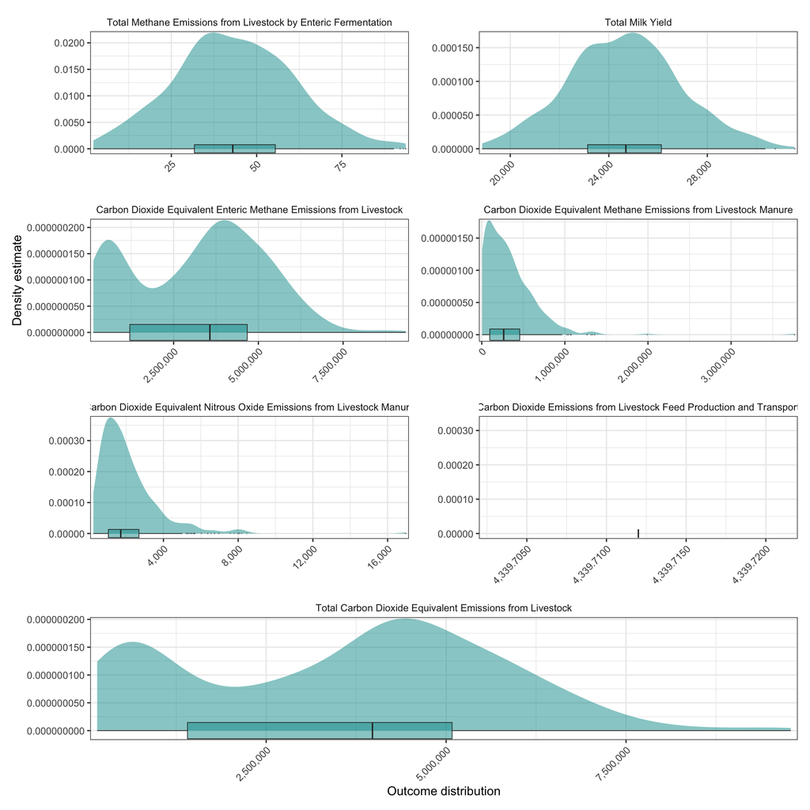

```r
# enteric_CH4=enteric_CH4,
enteric_CH4_dist_plot <- plot_distributions(mcSimulation_object = GHG_simulation_scenarios,
                   vars = "enteric_CH4",
                   method = "boxplot_density",
                   old_names = "enteric_CH4",
                   new_names = "Total Methane Emissions from Livestock by Enteric Fermentation") +
  theme(axis.title.x=element_blank(),
        axis.title.y=element_blank())

# milk_yield=sum(total_milk),
milk_yield_dist_plot <- plot_distributions(mcSimulation_object = GHG_simulation_scenarios,
                   vars = "milk_yield",
                   method = "boxplot_density",
                   old_names = "milk_yield",
                   new_names = "Total Milk Yield") +
  theme(axis.title.x=element_blank(),
        axis.title.y=element_blank())

# enteric_CH4_CO2eq=sum(enteric_CH4_CO2eq),
enteric_CH4_CO2eq_dist_plot <- plot_distributions(mcSimulation_object = GHG_simulation_scenarios,
                   vars = "enteric_CH4_CO2eq",
                   method = "boxplot_density",
                   old_names = "enteric_CH4_CO2eq",
                   new_names = "Carbon Dioxide Equivalent Enteric Methane Emissions from Livestock") +
  theme(axis.title.x=element_blank())

# mm_CH4_CO2eq=sum(mm_CH4_CO2eq),
mm_CH4_CO2eq_dist_plot <- plot_distributions(mcSimulation_object = GHG_simulation_scenarios,
                   vars = "mm_CH4_CO2eq",
                   method = "boxplot_density",
                   old_names = "mm_CH4_CO2eq",
                   new_names = "Carbon Dioxide Equivalent Methane Emissions from Livestock Manure") +
  theme(axis.title.x=element_blank(),
        axis.title.y=element_blank())

# mm_N2O_CO2eq=sum(mm_N2O_CO2eq),
mm_N2O_CO2eq_dist_plot <- plot_distributions(mcSimulation_object = GHG_simulation_scenarios,
                   vars = "mm_N2O_CO2eq",
                   method = "boxplot_density",
                   old_names = "mm_N2O_CO2eq",
                   new_names = "Carbon Dioxide Equivalent Nitrous Oxide Emissions from Livestock Manure") +
  theme(axis.title.x=element_blank(),
        axis.title.y=element_blank())

# feed_CO2=feed_CO2,
feed_CO2_dist_plot <- plot_distributions(mcSimulation_object = GHG_simulation_scenarios,
                   vars = "feed_CO2",
                   method = "boxplot_density",
                   old_names = "feed_CO2",
                   new_names = "Carbon Dioxide Emissions from Livestock Feed Production and Transport") +
  theme(axis.title.x=element_blank(),
        axis.title.y=element_blank())

# on_farm=sum(on_farm)
on_farm_dist_plot <- plot_distributions(mcSimulation_object = GHG_simulation_scenarios,
                   vars = "on_farm",
                   method = "boxplot_density",
                   old_names = "on_farm",
                   new_names = "Total Carbon Dioxide Equivalent Emissions from Livestock") +
  theme(axis.title.y=element_blank())

library(patchwork)
# remove the axis marks from the two lefthand-most plots and the x-axis title from the left and right plots

# plot with patchwork
layout <- "
           AAABBB
           CCCDDD
           EEEFFF
           GGGGGG
          "

enteric_CH4_dist_plot + milk_yield_dist_plot +
  enteric_CH4_CO2eq_dist_plot + mm_CH4_CO2eq_dist_plot +
  mm_N2O_CO2eq_dist_plot + feed_CO2_dist_plot +
  on_farm_dist_plot +
plot_layout(guides = "collect", design = layout)
```

# Uncertainty

As with the GHG Model, we apply the uncertainty functions on the `milk_yield` and `on_farm` variables. These come from the model results (400) of the `GHG_simulation_scenarios` model results to the `in_var` (x) and an outcome variable `out_var` (y). In the model we defined `on_farm` as the sum of Carbon Dioxide Equivalent Enteric Methane Emissions from Livestock (`enteric_CH4_CO2eq`), Carbon Dioxide Equivalent Methane Emissions from Livestock Manure (`mm_CH4_CO2eq`), Carbon Dioxide Equivalent Nitrous Oxide Emissions from Livestock Manure (`mm_N2O_CO2eq`) and Carbon Dioxide Emissions from Livestock Feed Production and Transport (`feed_CO2`).

```r
in_var  <- GHG_simulation_scenarios$y$milk_yield # "Total Milk Yield"
out_var <- GHG_simulation_scenarios$y$on_farm # "Total emissions"
```

## Milk_yield (x-axis) effect on on-farm GHG emissions (y-axis)

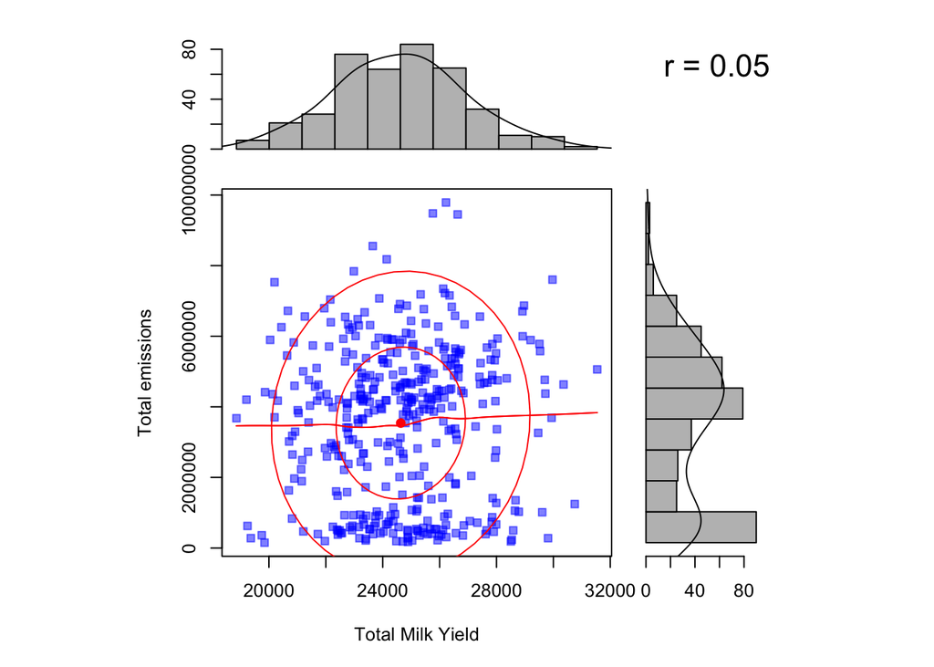

```
## [1] "Scatter plot of influencing variable (x) and outcome variable (y) with associated and estimated densities."
```

```r
uncertainty::varscatter(in_var = in_var,
                        out_var = out_var,
                        xlab = "Total Milk Yield",
                        ylab = "Total emissions")
```

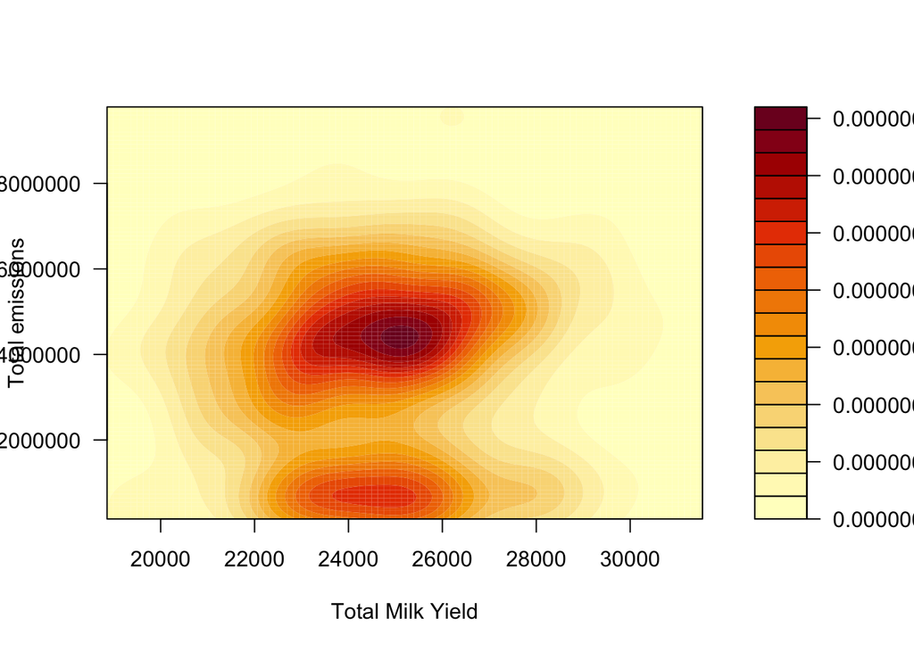

```
## [1] "Density surface plot of an expected influential variable (x) and an outcome variable of interest (y)."
```

```r
uncertainty::varkernel(in_var = in_var,
                       out_var = out_var,
                        xlab = "Total Milk Yield",
                        ylab = "Total emissions")
```

## Probability of GHG emissions for a given range of milk yield

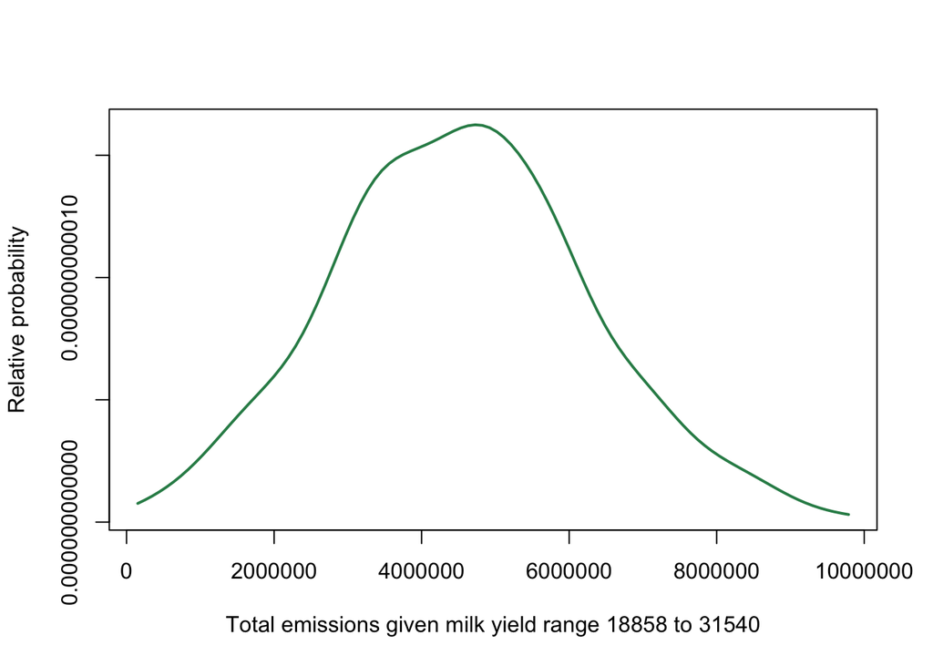

```
## [1] "Relative probability (y) of the outcome variable for the given values of the influencing variable (x)."
```

```r
uncertainty::varkernelslicerange(in_var = in_var,
                                 out_var = out_var,
                                 min_in_var = round(min(in_var)),
                                 max_in_var = round(max(in_var)),
                                 xlab_vars = "Total emissions given milk yield range")
```

This document was generated using R Markdown (Allaire et al. 2021).

# References

Allaire, JJ, Yihui Xie, Jonathan McPherson, Javier Luraschi, Kevin Ushey, Aron Atkins, Hadley Wickham, Joe Cheng, Winston Chang, and Richard Iannone. 2021. *Rmarkdown: Dynamic Documents for r*. https://CRAN.R-project.org/package=rmarkdown.